# データ解析論I第4講

## Table of content

## 前回の復習

## 関数とパッケージ

Rにおいてよく使う計算式は**関数**として用意されています．必要な関数は**パッケージ**をインストールすることで，適宜追加することができます．

- パッケージ：機能を拡張するもの．
  - 研究者など，たくさんの開発者が自身の研究上・仕事上のニーズに応じて拡張パッケージを用意している．
  - これを使えば様々な分析や操作が便利になる．
  - 必要に応じて，様々なパッケージを追加していくイメージ

## 以下の段取りを踏むことで利用可能となる．

1. パッケージをインストールする．
2. パッケージを読み込む．

1.については，一度行うだけで良い．  
2については必要に応じて適宜実施する．

以下にはその一例を示す．

```
install.packages(“dplyr”, dependencies = TRUE)
パッケージをインストールする．一度実行するだけで良い．

library(dplyr)
パッケージを読み込む，使うときには必ず入力する
```

## 他のデータを読み込む

今は皆さんに手入力でデータを打ち込んで貰いました．今度は，皆さんには“csvファイル”からデータを読み込んでもらおうと思います．Rの標準のデータ形式以外の他の形式のファイルを読み込むことを「インポート」と言います．

RStudioを使ってもらうと，次の手順でデータを読み込むことができます．

- “Import Dataset”をクリックする．
  - “From Text (readr)…”をクリックする．
  - 何かをインストールするように案内されたら，素直にインストールする．
- “Browse”をクリックする
  - 読み込みたいデータを選んで“Open”をクリックする．
  - データに併せて，クリックしていく．
    - 今回の場合は“First Row as Names”にチェックを入れる．これは1行目が各行のデータ名を示しているためである．
- “Import”をクリックしてデータを読み込む．
- 完了

下のコンソールには3つのコードが書かれます．1番目のコードは“readr”というパッケージを使うように，という指示をしています．2番目のコードは“データを読み込んで，こんな名前にしておいて下さい”を示しており，3番目のコードは“読み込んだデータを表示して下さい”を示している．

なお，このコード（特に上の2つ）は“>”を取り除いて上の“.R”ファイルに保存しておくと，次回以降便利です．

```
library(readr)
# パッケージreadrを使う
dataset <- read_csv("~/hogehoge/dataset.csv")
# datasetを読み込む
```

- Rのコード内で“#”と書くとコメントアウト（コードとして扱わず，メモとして使える）

なお，この“hogehoge”は読み込んだデータを保存した場所を示しており，人によって異なるので注意してください．

## データのダウンロード

- 「データの説明」ページにある「こちらからダウンロードしてください」というところから，csvファイルをダウンロードしてください．

## 注意：この授業で取り扱うデータについて

このデータはゴトウが実施した1926人分のデータのうち，ランダムに選んだ963人分のデータです．まだ，データの中身は「データの概要」に記載してあるので，そちらを参考にしてください．

読み込んだデータの記述統計量を算出します．ここでは人々の主観的幸福度について記述統計量を算出します．

## 主観的幸福度とは：

主観的幸福度とは人が感じている幸福度を示したものです．ここでは「現在，あなたはどの程度幸せですか？「とても幸せ」を10点，「とても不幸せ」を0点とすると，何点くらいになると思いますか？」として尋ねたものです．

昨今では主観的幸福度は「幸福の経済学」という分野で注目されており．研究が積み重ねられています．

- 詳細は秋学期に開講する「経済と情報行動」の中で触れます．

それでは，記述統計量を出してみましょう．特に，複数列あるデータの場合は$を使って，「データセットの中のこのデータ列について平均値を出して下さい」というように指定してあげます．

## 平均・分散・標準偏差・度数など．

```r
library(readr)
exdataset <- read_csv("/Users/akira/Dropbox/Education/2020MEIJI/[3_Wed1]Data_Analytics/analysis/data/exdataset.csv")
```

```r
library(ggplot2)
```

```r
# データを読み込めたら，以下をコピペしてください．
# いろいろなものの順番を理解しやすいように並べ替えます．

## Reordering exdataset$ARE
exdataset$ARE <- factor(exdataset$ARE, levels=c("Kanto", "Hokkaido", "Tohoku", "Chubu", "Kinki", "Chugoku", "Shikoku", "Kyushu"))

## Reordering exdataset$MAR
exdataset$MAR <- factor(exdataset$MAR, levels=c("NotMarried", "Married"))

## Reordering exdataset$CHI
exdataset$CHI <- factor(exdataset$CHI, levels=c("NoChild", "Child"))
```

## 記述統計量をコードで算出する

### **平均値**を算出してみる．

主観的幸福度(SUB_HAP)の平均値

```r
mean(exdataset$SUB_HAP)
```

```
## [1] 6.002077
```

### **分散**を算出してみる．

主観的幸福度(SUB_HAP)の分散

```r
var(exdataset$SUB_HAP)
```

```
## [1] 5.503114
```

### **標準偏差**を算出してみる．

主観的幸福度(SUB_HAP)の標準偏差

```r
sd(exdataset$SUB_HAP)
```

```
## [1] 2.345872
```

### 主観的幸福度(SUB_HAP)の**ヒストグラム**

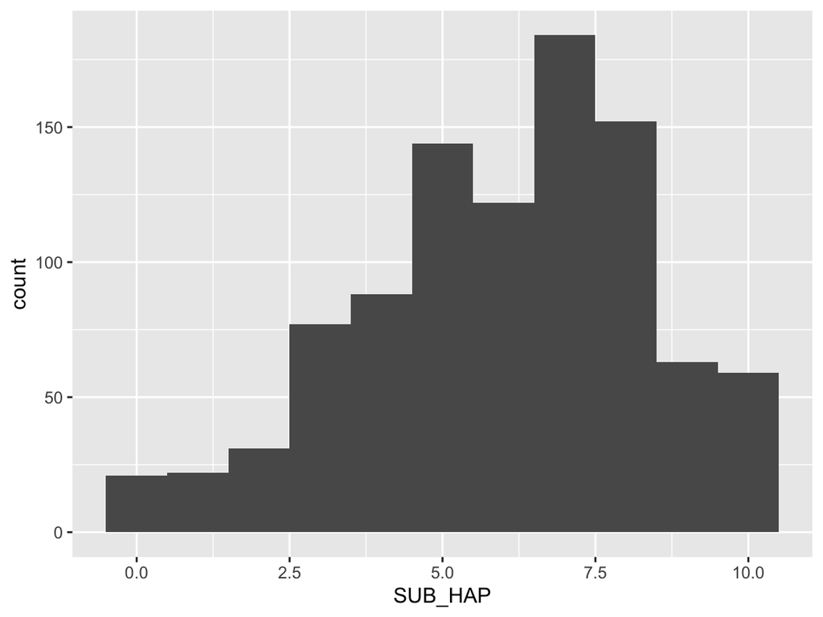

```r
g <- ggplot(exdataset, aes(x = SUB_HAP)) + geom_histogram(binwidth = 1.0)
g
```

### 運命(SPN_UNM)の**頻度**を数えてみる．

```r
table(exdataset$SPN_UNM)
```

```
##
##   1   2   3   4
## 153 381 355  74
```

### ついで運命(SPN_UNM)のに**ヒストグラム**も作ってみよう

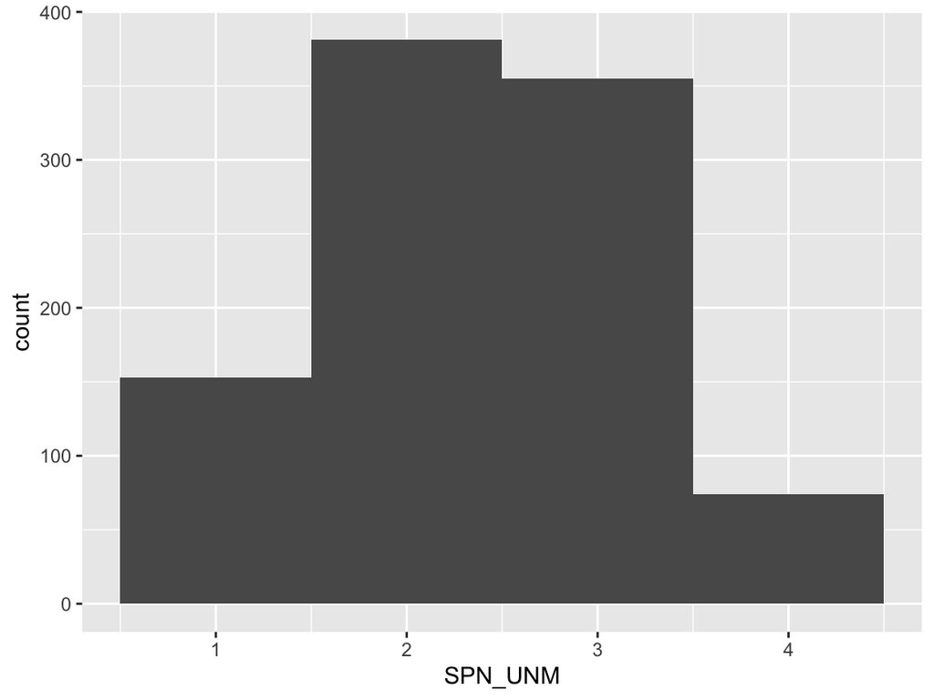

```r
g <- ggplot(exdataset, aes(x = SPN_UNM)) + geom_histogram(binwidth = 1.0)
g
```

### 世代の**頻度**を数えてみる．

```r
table(exdataset$F_GEN)
```

```
##
## 10dai 20dai 30dai 40dai 50dai 60dai 70dai
##     8   140   361   358    77    18     1
```

- 基本的には『関数』を用いた計算方法を紹介する．

## 同じことをjamoviでやってみよう．

- 動画を参照のこと

## 再現可能性(Reproducibility)の重要性

## 再現可能性に関する様々な議論と定義（[Kulkarni, 2017](https://www.editage.jp/insights/irreproducibility-is-the-lack-of-an-accepted-definition-a-problem-in-itself)）

### Goodmanによる定義（[Goodman et.al, 2016](https://stm.sciencemag.org/content/8/341/341ps12)）：

- **方法の再現可能性**(Methods reproducibility)：反復可能性にもっとも近い．研究方法とデータに関する十分な情報が提供され、同じ手順を反復できるようになっていることを意味する．
- 結果の再現可能性(Results reproducibility)：「方法の再現可能性」と密接に関連している．「元の実験と可能な限り同じ手順で，独立した実験を実施し，同じ結果を得ること」を意味する．
- 推論の再現可能性(Inferential reproducibility)：先の2つの再現可能性とは異なる。別の研究から同じ推論が導かれることもあれば，同じデータから別の結果が推測されることもある．このため，推論の再現可能性とは「独立した再現実験もしくは元の研究の再分析から，質的に類似した結果を導くこと」を意味する．

### Stoddenによる定義（[Stodden, 2014](https://web.stanford.edu/~vcs/talks/OpenConNov152014-STODDEN.pdf)）：

- 実証的再現可能性(Empirical reproducibility)：物理的に実験を繰り返して実証する必要なすべての情報が提供されていることを意味する．この定義は，グッドマン氏の「方法の再現可能性」の定義に近い．
- **計算／統計的再現可能性**(Computational and statistical reproducibility)：研究における計算結果や分析結果を再び行うために欠かせないリソースが提供されていることを意味する．

### Bakerによる定義（[Baker, 2016](https://www.nature.com/news/muddled-meanings-hamper-efforts-to-fix-reproducibility-crisis-1.20076)）：

- **分析的反復**(Analytic replication)：単に元データを再分析して結果を再現すること．
- 直接的反復(Direct replication)：元の実験と同じ条件，材料，方法を利用しようとすること．
- 体系的反復(Systematic replication)：異なる実験条件で結果を再現しようとすること．（例えば，異なる細胞株やマウス株で実験を行うことなど．）
- 概念的反復(Conceptual replication )：ある概念の一般的な正当性を示そうとすること．異なる有機体を使用する場合も含まれる．

## 再現可能なデータ分析とレポート作成のメリット（高橋, 2018）

### **信頼性**の向上

- データ解析：得たデータを分析結果やグラフに変換すること
- 同じデータからいつでもどこでも誰でも同じ結果を得られる必要がある
  - 皆さんの分析結果がゴトウが授業でやっている結果と一致しなかったら不安になりませんか？
- 分析が再現できることは，その研究の信頼性が高いことを示している．
- 統計処理はあくまでも「プロセス」なので，決まった形式が存在している．同じ分析結果を出力するための技術は身につける必要がある．
- その意味では，jamoviはRよりも「プロセスの自由度」が低いため，Rよりもハードルが低い．
- しかし，社会に出てから求められるのはRやPythonを使える人材ですぜ．
- ちょっと頑張ってみても面白いんですぜ．

### **間違い**の検証

- 人間の作業には何らかの間違いが発生しがち．
- 特に，分析過程でコードのどこかに間違いが存在することがある．
- 再現可能なデータ分析を行うことで，間違いを探すことができる．
- **間違いは罪ではないが，「どこで間違ったかわからなくする」のは罪である．**
  - 間違ったことを責めるのではなく，どこに原因があるのかを探す&見つけられることが重要．

### **作業効率**の向上

- 作業の大半を自動化できており，作業時間を減少することができる．
- 間違いの検証にかかる時間も大幅に減少することが可能となる．
- 本当はRの方が作業効率を高められるんですが．．．．
  - 同じコードを使いまわしできる．
  - jamoviではいちいちデータごとに処理を用意しなければいけない．
  - これがほんとにめんどくなる．
    - だからRを，Rを使うのじゃ．．．

## 作業を進める際には以下のことを気をつけましょう．

- データソースを手で加工，整形していないか
  - どんなことをやったかわからなくなりがちなので，極力データはjamoviやRStudioの上で加工するようにしましょう．
  - とはいえ，最初はいきなりこれも厳しいか．
- コピペを行っていないか
  - RのコードをRスクリプトにコピペする作業は除く
- コンソールに直接コマンドを入力していないか
  - Rスクリプトを作成する際の動作確認やインストールするためのコマンドはコンソールに直接入力して良い
- 手作業で結果やグラフの保存を行っていないか
- 結果やグラフをコピペや手作業でレポートに貼り付けていないか
  - Rマークダウンでレポートを作る場合

## jamoviでグラフを作ってみよう

## グラフの作成の基礎

- [こちら](https://bookdown.org/sbtseiji/lswjamoviJ/ch-graphics.html)をご覧ください．
  - このページを見ながら一緒に作業していきましょう．
  - 前回作業したファイルの続きで構いません．

## いくつか記述統計量出したり，グラフを作ってみよう

- 独裁者ゲームの両親条件(DIC_PAR)に関する平均値・分散・標準偏差の算出，および箱ひげ図・棒グラフの作成．
- 独裁者ゲームの友人条件(DIC_FRI)ならびに他者条件(DIC_OTH)に関する平均値・分散・標準偏差の算出，および箱ひげ図・棒グラフの作成．
- 独裁者ゲーム両親条件・友人条件・他者条件に関する相関行列の作成

## いくつか記述統計量出したり，グラフを作ってみよう

- 自然関連データ（自然運命(SPN_UNM)・自然感謝(SPN_THK)・自然恐怖(SPN_FEA)・自然生存(SPN_LIV)・自然大切(SPN_IMP)）関する平均値・分散・標準偏差の算出，および箱ひげ図・棒グラフの作成．
- 独裁者ゲーム両親条件・友人条件・他者条件に関する相関行列の作成

## 再現可能性を高めるRMarkdownの例

## コロナウイルス関係のデータを見てみましょう．

- パッケージ“COVID19”：
- 別途動画でご確認ください．

## 本当は全部RStudio & Rmarkdownで作業したいのですが，，，

- 個人的な趣味です．
- データを書き出したので，csvファイルにして，jamoviでいじってみましょう．
- 別途動画をご確認ください
  - できれば皆さんにRMarkdown形式で一回データを取り出してもらえればと思うのですが，必ずしもうまくいくとは限りません．
  - 必要なパッケージのインストールに失敗したり．
  - 私も直前にRのバージョンアップをしてエライ目に合いました．．．．
  - 別途授業用サイトにデータを置いておくので，そちらをダウンロードして作業しましょう．

## Rmarkdownファンへの資料：

## Rmarkdownを使うときにいじるべきところ．

- YAMLヘッダー：
  - RMarkdownのファイルのメタデータを設定
  - 著者情報の編集，出力ファイルの切り替え，目次の作成などの設定が可能
  - その他テンプレートなどをいろいろ組み合わせる．
- チャンク：
  - コードを記述する部分
  - この間にRコードを記述する．
  - チャンクオプション：各チャンク内の動作を指定する．

| チャンクオプション | デフォルト | オプションの意味 |
| --- | --- | --- |
| echo | TRUE | チャンク内での計算結果を出力として表示するか(TRUE)否か(FALSE)． |
| error | TRUE | チャンク内でのエラーを表示するか否か． |
| eval | TRUE | チャンク内での計算結果を評価するか否か |
| fig.cap |  | 図の注釈：fig.cap=“Figure1” |
| fig.height | 7 | 図の縦幅（インチ） |
| fig.width | 7 | 図の横幅（インチ） |

| チャンクオプション | デフォルト | オプションの意味 |
| --- | --- | --- |
| include | TRUE | チャンク・実行結果を出力するか否か(FALSEでもコードは評価される)． |
| message | TRUE | チャンク内でのパッケージの読み込みなどのメッセージを表示するか否か． |
| warning | TRUE | チャンク内での警告を表示するか否か． |

## 今日のTake Home Messages

## **レポーティング**が重要！

- 分析した結果を他の人に伝える必要がある．
- 自身の記録としても残しておく必要がある．

## **再現性**が重要！

- 自身が行った分析を再度確認するために．
- 他の人にデータの分析結果の妥当性を確認してもらうために．
- コードと合わせて説明できることが望ましい．
  - 授業の際には科学の抱える再現性の問題についても紹介する．

## Rでデータを扱う時に注意すべきこと

- 必ず数字／文字は半角で入力する．
- 日本語は使わずにローマ字を使用する．
- コメントアウト（コードではなく，関係ないメモを入れること）をするときは半角の「#」から始める．
  - メモする内容は全角でもよい．
- ファイル名およびパスには決して全角の文字（ひらがな，カタカナ，漢字，全角スペースなど）を入れてはいけない．
  - 半角英数字だけにする．
- 慌てずに落ち着いて操作すれば，決して難しくない．
  - 1つずつ落ち着いて作業することを心がける．
- 「わからない」ことを恐れない
  - 周りの友人に聞いたり，教員に確認したりしよう．
- 文字化け対策に**[こちら](https://docs.google.com/document/d/1CYF6LeFeGV9dTWHGuznkO0Tm4RnhAu2KatdSqFn7bmU/edit)** のp8以降を確認して設定しよう．

## 演習問題

## 問題

### 別途ファイルから5/7現在のコロナウイルス関係のデータを保存して，以下の値を算出してください．

- 検査数（test），感染者数（confirmed），回復者数（recovered），死者数(deaths)の平均値・分散・標準偏差を算出してください．さらに，箱ひげ図および棒グラフを作成しましょう．
- 検査数（test），感染者数（confirmed），回復者数（recovered），死者数(deaths)およびGDP(gdp)の相関行列を作成しましょう．
- その他，このデータを使って色々考えてみましょう．
  - 色々グラフを作ったりしてみましょう．